# Atividade Prática 5 — Respostas

Econometria Aplicada à Finanças  
Mestrado Profissional em Administração

Autor

Jonathan Vargas Silva

Data de Publicação

8 de setembro de 2026

# Questão 1: Autocorrelação e inferência

## **a.** Estimação do modelo

Estime por MQO o modelo especificado no enunciado utilizando `lm()` e armazene o resultado em um objeto denominado `modelo`.

```r
# Estime o modelo
modelo <- stats::lm(
  diff_housing ~ diff_mr + diff_industry + diff_unemp,
  data = dados
)
modelo
```

```
Call:
stats::lm(formula = diff_housing ~ diff_mr + diff_industry +
    diff_unemp, data = dados)

Coefficients:
  (Intercept)        diff_mr  diff_industry     diff_unemp
        -4.34         -41.60          38.39          12.20
```

Interprete economicamente o coeficiente de `diff_mr` e classifique o modelo como estático ou dinâmico, justificando sua resposta.

O modelo é estático, porque relaciona a variação da construção residencial em determinado mês apenas com variações de outras variáveis no mesmo mês. Não há nenhuma variável defasada entre as explicativas.

## **b.** Diagnóstico da autocorrelação

Examine a FAC dos resíduos:

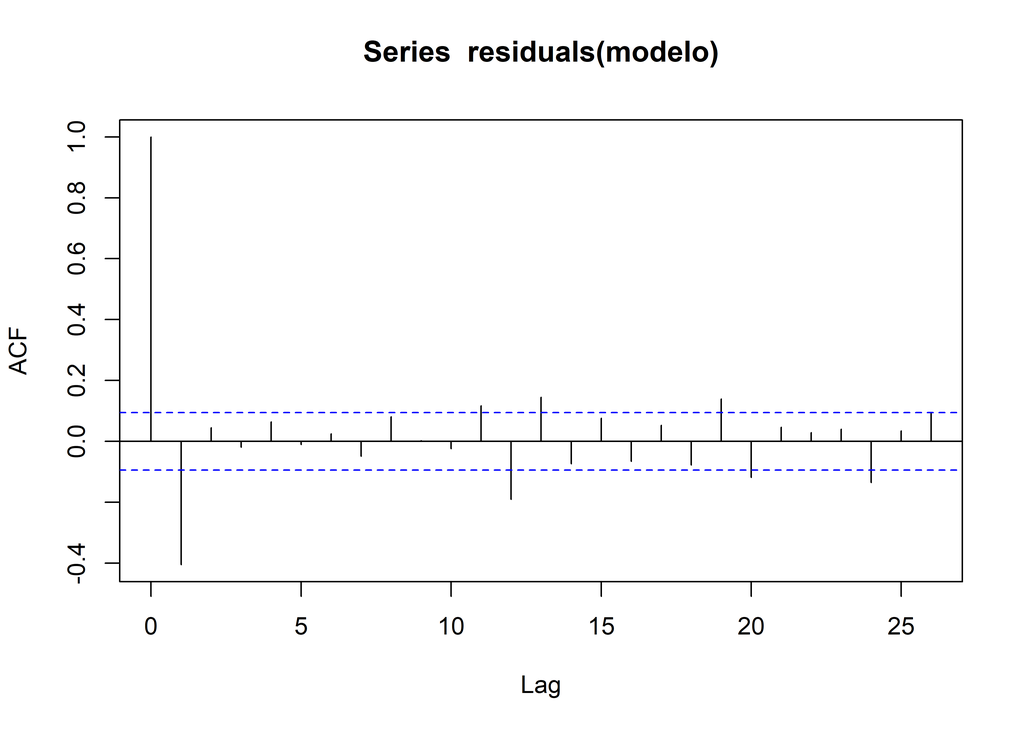

```r
# Exibe a FAC dos resíduos
acf(residuals(modelo))
```

Com base no gráfico, avalie a presença de autocorrelação e o sinal sugerido nas primeiras defasagens.

1. No gráfico em questão observa-se a presença de autocorrelação.
2. O sinal da autocorrelação sugerida nas primeiras defasagens é a proporcionalidade inversa em que os resíduos se afastam da média.

Realize o teste de Breusch–Godfrey para autocorrelação de primeira ordem. Apresente as hipóteses, o resultado, a decisão para $\alpha=5\%$ e sua interpretação.

**Dica:** utilize `lmtest::bgtest()` com `order = 1`.

```r
# Execute o teste de Breusch–Godfrey
resultado_bg <- lmtest::bgtest(modelo, order = 1)
resultado_bg
```

```
    Breusch-Godfrey test for serial correlation of order up to 1

data:  modelo
LM test = 72.7, df = 1, p-value <0.0000000000000002
```

## **c.** Inferência com erros-padrão de Newey–West

Calcule a inferência com erros-padrão de Newey–West conforme especificado no enunciado.

Armazene:

- o estimador da matriz de covariância em `vcov_nw`;
- o resultado de `lmtest::coeftest()` em `resultado_nw`.

Use `prewhite = FALSE` e `adjust = TRUE`.

```r
# Estime a matriz de covariância Newey-West
vcov_nw <- sandwich::NeweyWest(
  modelo,
  prewhite = FALSE,
  adjust = TRUE
)

# Calcule a inferência com Newey-West
resultado_nw <- lmtest::coeftest(
  modelo,
  vcov. = vcov_nw
)

# Apresente os resultados
resultado_nw
```

```
t test of coefficients:

              Estimate Std. Error t value Pr(>|t|)
(Intercept)      -4.34       2.98   -1.46  0.14616
diff_mr         -41.60      18.80   -2.21  0.02740 *
diff_industry    38.39       9.81    3.91  0.00011 ***
diff_unemp       12.20      13.42    0.91  0.36374
---
Signif. codes:  0 '***' 0.001 '**' 0.01 '*' 0.05 '.' 0.1 ' ' 1
```

Explique por que os coeficientes permanecem os mesmos, por que os erros-padrão podem mudar e por que Newey–West é adequado ao problema diagnosticado.

## **d.** Comparando a inferência

Compare a inferência convencional de MQO com a inferência obtida utilizando erros-padrão de Newey–West.

```r
# Obtém a inferência convencional
resultado_conv <- lmtest::coeftest(modelo)

# Calcula os intervalos de confiança de 95%
ic_conv <- lmtest::coefci(modelo)

ic_nw <- lmtest::coefci(
  modelo,
  vcov. = vcov_nw
)

# Organiza os resultados para comparação
comparacao <- tibble(
  coeficiente = rownames(resultado_conv),
  estimativa = resultado_conv[, "Estimate"],
  ep_convencional = resultado_conv[, "Std. Error"],
  ic95_conv_inferior = ic_conv[, 1],
  ic95_conv_superior = ic_conv[, 2],
  p_convencional = resultado_conv[, "Pr(>|t|)"],
  ep_newey_west = resultado_nw[, "Std. Error"],
  ic95_nw_inferior = ic_nw[, 1],
  ic95_nw_superior = ic_nw[, 2],
  p_newey_west = resultado_nw[, "Pr(>|t|)"]
)

# Formata os valores-p para apresentação
comparacao_exibicao <- comparacao |>
  mutate(
    p_convencional = format.pval(
      p_convencional,
      digits = 3,
      eps = 0.001
    ),
    p_newey_west = format.pval(
      p_newey_west,
      digits = 3,
      eps = 0.001
    )
  )

# Apresenta os resultados
knitr::kable(
  comparacao_exibicao,
  digits = 3,
  caption = paste(
    "Comparação entre a inferência convencional (MQO)",
    "e a inferência de Newey–West."
  )
)
```

Comparação entre a inferência convencional (MQO) e a inferência de Newey–West.

| coeficiente | estimativa | ep_convencional | ic95_conv_inferior | ic95_conv_superior | p_convencional | ep_newey_west | ic95_nw_inferior | ic95_nw_superior | p_newey_west |
| --- | --- | --- | --- | --- | --- | --- | --- | --- | --- |
| (Intercept) | -4.341 | 4.635 | -13.451 | 4.769 | 0.3495 | 2.982 | -10.202 | 1.520 | 0.1462 |
| diff_mr | -41.604 | 23.137 | -87.081 | 3.874 | 0.0729 | 18.796 | -78.548 | -4.659 | 0.0274 |
| diff_industry | 38.392 | 7.361 | 23.923 | 52.861 | <0.001 | 9.809 | 19.111 | 57.673 | <0.001 |
| diff_unemp | 12.203 | 12.463 | -12.294 | 36.700 | 0.3281 | 13.421 | -14.177 | 38.583 | 0.3637 |

Com base na comparação:

1. as estimativas dos coeficientes mudaram quando utilizamos Newey–West? Explique;
2. os erros-padrão mudaram todos na mesma direção? Identifique pelo menos um coeficiente cujo erro-padrão aumentou e um cujo erro-padrão diminuiu, caso isso ocorra;
3. compare os intervalos de confiança convencionais com os intervalos obtidos com Newey–West. Houve mudanças relevantes na incerteza associada às estimativas?
4. alguma conclusão inferencial é alterada ao utilizar Newey–West, considerando $\alpha=5\%$?
5. escolha **um coeficiente** e faça uma interpretação conjunta de:
   - sua magnitude;
   - sua incerteza;
   - seu intervalo de confiança;
   - sua evidência estatística.

Não limite sua interpretação à comparação do valor-$p$ com o nível de significância.